# P4作业——红酒质量探索与分析

上述分析中有多个成分的分布呈现偏态特征，该类分布向右侧延伸的长尾中可能会隐藏部分有用信息。我们单独对各变量取对数后重画分布图，看看能否发掘更多信息。

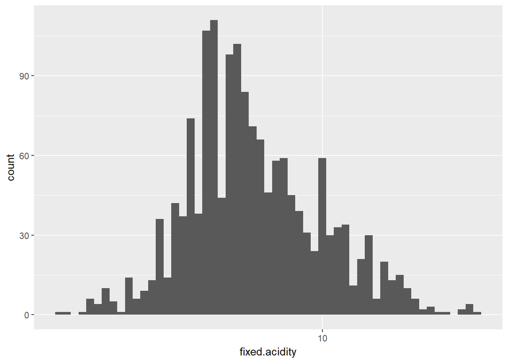

```r
# histograms of different variables
qplot(x = fixed.acidity, data = wine, geom = 'histogram', binwidth = 0.01, log = 'x')
```

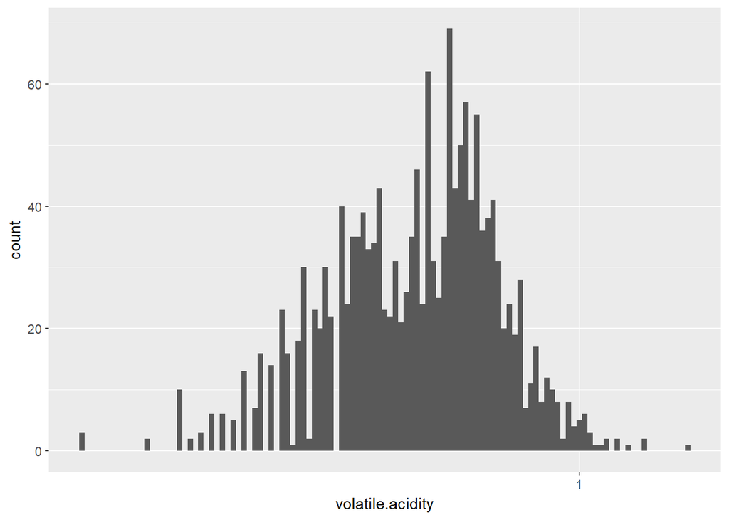

```r
qplot(x = volatile.acidity, data = wine, geom = 'histogram', binwidth = 0.01, log = 'x')
```

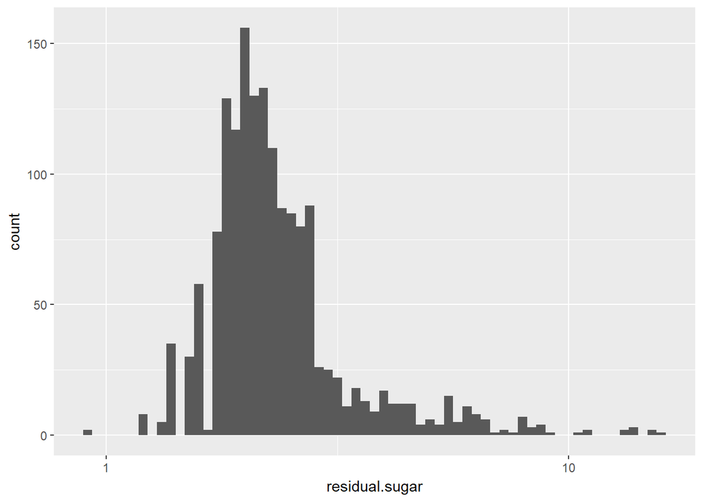

```r
qplot(x = residual.sugar, data = wine, geom = 'histogram', binwidth = 0.02, log = 'x')
```

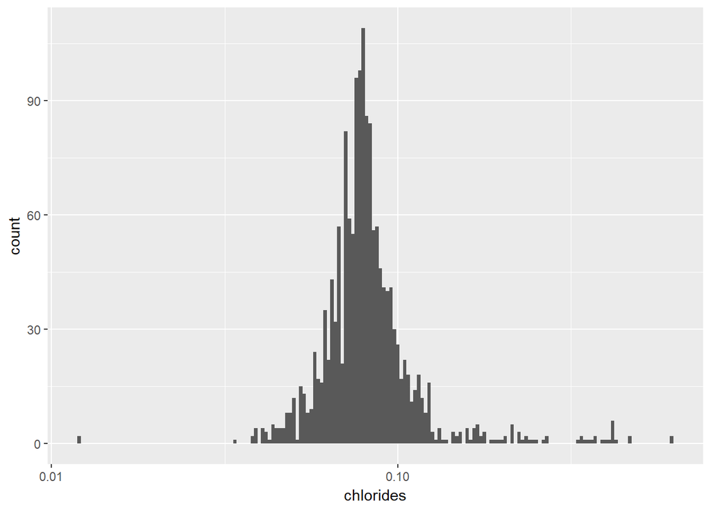

```r
qplot(x = chlorides, data = wine, geom = 'histogram', binwidth = 0.01, log = 'x')
```

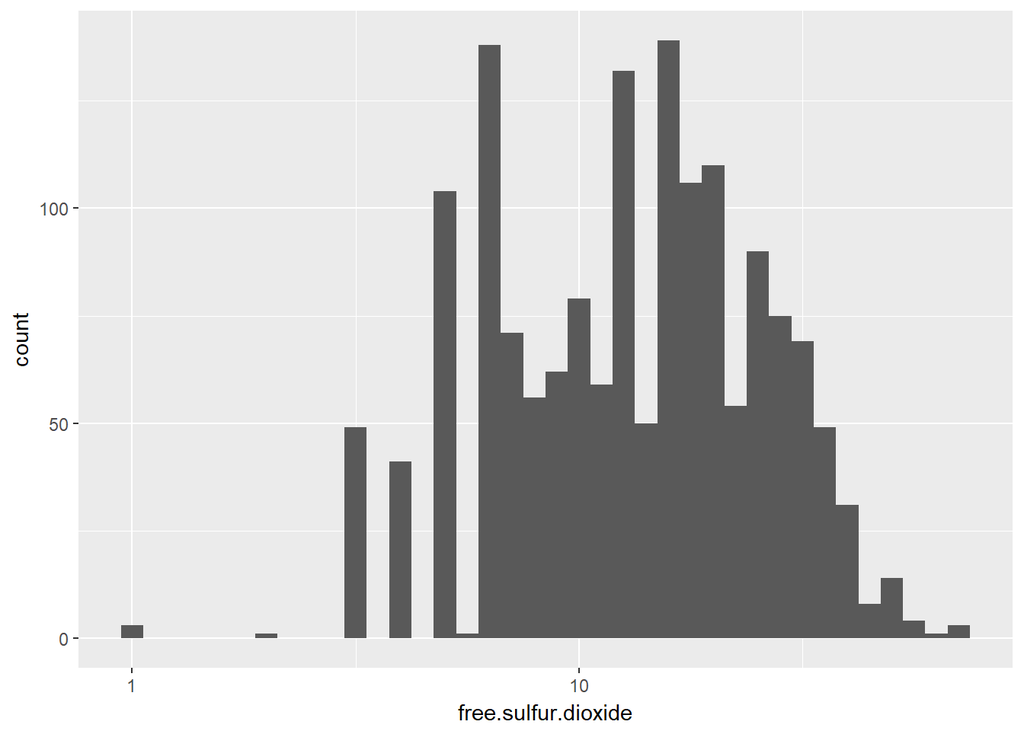

```r
qplot(x = free.sulfur.dioxide, data = wine, geom = 'histogram', binwidth = 0.05, log = 'x')
```

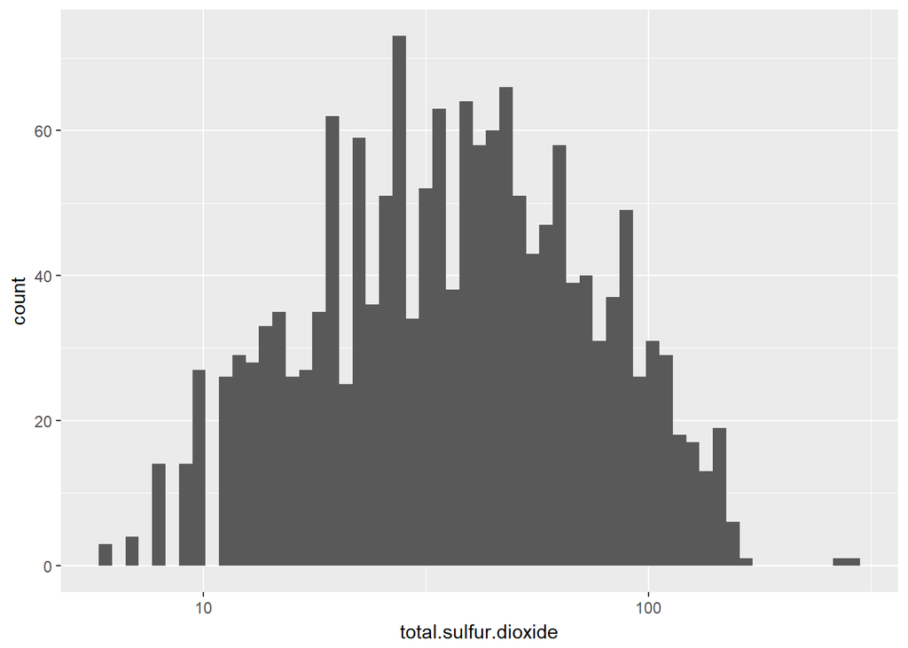

```r
qplot(x = total.sulfur.dioxide, data = wine, geom = 'histogram', binwidth = 0.03, log = 'x')
```

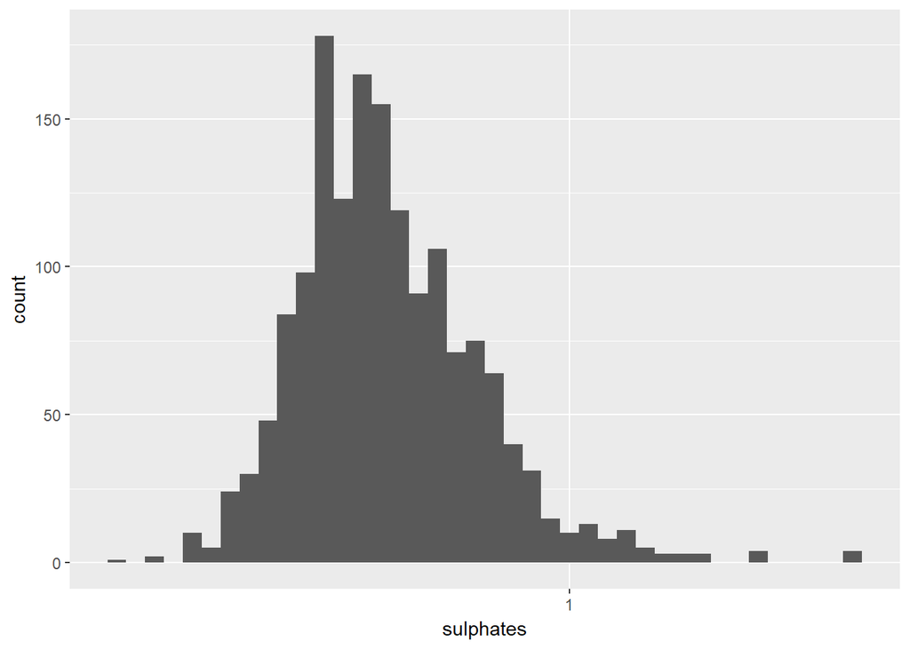

```r
qplot(x = sulphates, data = wine, geom = 'histogram', binwidth = 0.02, log = 'x')
```

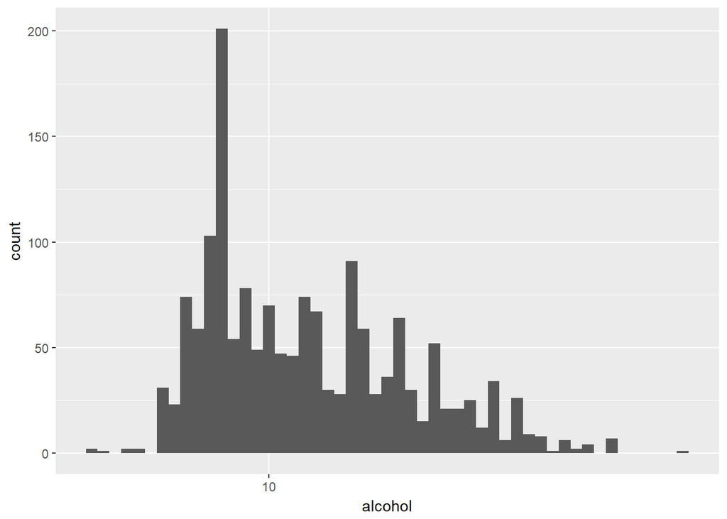

```r
qplot(x = alcohol   , data = wine, geom = 'histogram', binwidth = 0.005, log = 'x')
```

似乎没有什么特别发现~囧。

# 单变量分析

## 数据集的结构

数据包含了1599条数据，每条数据对应一种红酒，每种红酒包含11种测定的化学成分（非挥发性酸、挥发性酸、柠檬酸、剩余糖分、氯化物、游离二氧化硫、总二氧化硫、密度、PH值、硫酸盐、酒精）、1种人为评定的酒的品质分数，该分数从0分（最差）到10分（最佳）。其他观察结果包括： 1）品质分数、密度、PH值三个变量基本呈现正态分布规律，其余变量多少都呈现出偏态分布规律； 2）品质分数出现次数最多的集中在5分和6分，没有低于3分和高于8分的记录； 3）部分变量数值范围较大，发现有包含异常值的情况。

## 数据集中感兴趣的主要特征

最感兴趣的特征是品质分数，我想了解该变量与其他变量的关系，即各种化学成分如何影响酒的品质。

## 数据集内其他哪些特征可以帮助探索兴趣点

由于分布显示出正态分布特性，个人预计密度、PH值对品质可能没有直接影响，品质评分更多与剩下的变量如非挥发性酸、挥发性酸、柠檬酸、剩余糖分、氯化物、游离二氧化硫、总二氧化硫、硫酸盐、酒精相关。

## 是否创建新变量

根据[PH值的定义](http://baike.sogou.com/v506640.htm?fromTitle=PH%E5%80%BC)，将PH值转换为H+离子浓度，公式为：PH=－log10[H+]，[H+]=10^(-PH)，其中[H+]为氢离子浓度，单位mol/L。

```r
# unit : mol/L
wine$H.concentration <- 10^(-wine$pH)
```

由于呈现酸性的PH值与成分中酸性物质的含量相关，故将成分中三种酸性物质：非挥发性酸、挥发性酸、柠檬酸转化为各自物质含量。根据[B格小文](http://blog.sina.com.cn/s/blog_8cad55d90102xo10.html)所描述，非挥发性酸中主要包含酒石酸、苹果酸（此处假设都是酒石酸），挥发性酸主要包含醋酸，因此根据:[酒石酸](http://baike.sogou.com/v261917.htm?fromTitle=%E9%85%92%E7%9F%B3%E9%85%B8)、[醋酸](http://baike.sogou.com/v1192371.htm?fromTitle=%E9%86%8B%E9%85%B8)、[柠檬酸](http://baike.sogou.com/v256007.htm?fromTitle=%E6%AA%B8%E6%AA%AC%E9%85%B8)所给出的分子式，得到： 酒石酸C4H6O6，分子量150； 醋酸CH3COOH，分子量60； 柠檬酸C6H8O7，分子量192。

折算出各酸性成分含量转换公式：含量[mol/L] = 浓度[g/cm^3] * 1000[cm^3/L] / 分子量[g/mol]，依据该公式得到三种酸的物质含量。

```r
# transform units of variables, following variables unit: mol/L
wine$f.acid.amount <- wine$fixed.acidity * 1000 /150
wine$v.acid.amount <- wine$volatile.acidity * 1000 / 60
wine$c.acid.amount <- wine$citric.acid * 1000 / 192
str(wine)
```

```
## 'data.frame':    1599 obs. of  17 variables:
##  $ X                   : int  1 2 3 4 5 6 7 8 9 10 ...
##  $ fixed.acidity       : num  7.4 7.8 7.8 11.2 7.4 7.4 7.9 7.3 7.8 7.5 ...
##  $ volatile.acidity    : num  0.7 0.88 0.76 0.28 0.7 0.66 0.6 0.65 0.58 0.5 ...
##  $ citric.acid         : num  0 0 0.04 0.56 0 0 0.06 0 0.02 0.36 ...
##  $ residual.sugar      : num  1.9 2.6 2.3 1.9 1.9 1.8 1.6 1.2 2 6.1 ...
##  $ chlorides           : num  0.076 0.098 0.092 0.075 0.076 0.075 0.069 0.065 0.073 0.071 ...
##  $ free.sulfur.dioxide : num  11 25 15 17 11 13 15 15 9 17 ...
##  $ total.sulfur.dioxide: num  34 67 54 60 34 40 59 21 18 102 ...
##  $ density             : num  0.998 0.997 0.997 0.998 0.998 ...
##  $ pH                  : num  3.51 3.2 3.26 3.16 3.51 3.51 3.3 3.39 3.36 3.35 ...
##  $ sulphates           : num  0.56 0.68 0.65 0.58 0.56 0.56 0.46 0.47 0.57 0.8 ...
##  $ alcohol             : num  9.4 9.8 9.8 9.8 9.4 9.4 9.4 10 9.5 10.5 ...
##  $ quality             : int  5 5 5 6 5 5 5 7 7 5 ...
##  $ H.concentration     : num  0.000309 0.000631 0.00055 0.000692 0.000309 ...
##  $ f.acid.amount       : num  49.3 52 52 74.7 49.3 ...
##  $ v.acid.amount       : num  11.67 14.67 12.67 4.67 11.67 ...
##  $ c.acid.amount       : num  0 0 0.208 2.917 0 ...
```

## 是否存在异常分布，是否对数据进行整理，为什么

前面章节发现，柠檬酸含量中出现大量0值，但是对这些数据进行查看并未发现异常，故全部保留。 通过各变量的分布图，下列变量疑似存在偏大的异常值：柠檬酸、残留糖分、氯化物、游离二氧化硫、总二氧化硫、硫酸盐。通过限制分位数99%将异常值去掉。

```r
# restrict data by quantile values of 99%
tidy.wine <- subset(wine, (wine$citric.acid < quantile(wine$citric.acid, 0.99)))
tidy.wine <- subset(tidy.wine, (tidy.wine$residual.sugar < quantile(tidy.wine$residual.suga, 0.99)))
tidy.wine <- subset(tidy.wine, (tidy.wine$chlorides < quantile(tidy.wine$chlorides, 0.99 )))
tidy.wine <- subset(tidy.wine, (tidy.wine$free.sulfur.dioxide < quantile(tidy.wine$free.sulfur.dioxide, 0.99 )))
tidy.wine <- subset(tidy.wine, (tidy.wine$total.sulfur.dioxide < quantile(tidy.wine$total.sulfur.dioxide, 0.99 )))
tidy.wine <- subset(tidy.wine, (tidy.wine$sulphates < quantile(tidy.wine$sulphates, 0.99 )))

# summary(wine)
summary(tidy.wine)
```

```
##        X          fixed.acidity    volatile.acidity  citric.acid
##  Min.   :   1.0   Min.   : 4.600   Min.   :0.1200   Min.   :0.0000
##  1st Qu.: 411.5   1st Qu.: 7.100   1st Qu.:0.3900   1st Qu.:0.0900
##  Median : 815.0   Median : 7.900   Median :0.5200   Median :0.2500
##  Mean   : 808.2   Mean   : 8.285   Mean   :0.5285   Mean   :0.2614
##  3rd Qu.:1203.5   3rd Qu.: 9.150   3rd Qu.:0.6400   3rd Qu.:0.4200
##  Max.   :1599.0   Max.   :15.900   Max.   :1.5800   Max.   :0.7000
##  residual.sugar    chlorides       free.sulfur.dioxide
##  Min.   :0.900   Min.   :0.01200   Min.   : 1.00
##  1st Qu.:1.900   1st Qu.:0.07000   1st Qu.: 7.00
##  Median :2.200   Median :0.07900   Median :13.00
##  Mean   :2.409   Mean   :0.08272   Mean   :15.11
##  3rd Qu.:2.600   3rd Qu.:0.08900   3rd Qu.:21.00
##  Max.   :8.100   Max.   :0.34300   Max.   :47.00
##  total.sulfur.dioxide    density             pH         sulphates
##  Min.   :  6.00       Min.   :0.9901   Min.   :2.88   Min.   :0.3300
##  1st Qu.: 21.00       1st Qu.:0.9956   1st Qu.:3.22   1st Qu.:0.5500
##  Median : 36.00       Median :0.9967   Median :3.32   Median :0.6200
##  Mean   : 43.65       Mean   :0.9967   Mean   :3.32   Mean   :0.6427
##  3rd Qu.: 58.50       3rd Qu.:0.9978   3rd Qu.:3.41   3rd Qu.:0.7200
##  Max.   :142.00       Max.   :1.0031   Max.   :4.01   Max.   :1.1600
##     alcohol         quality      H.concentration     f.acid.amount
##  Min.   : 8.40   Min.   :3.000   Min.   :9.772e-05   Min.   : 30.67
##  1st Qu.: 9.50   1st Qu.:5.000   1st Qu.:3.890e-04   1st Qu.: 47.33
##  Median :10.20   Median :6.000   Median :4.786e-04   Median : 52.67
##  Mean   :10.45   Mean   :5.638   Mean   :5.073e-04   Mean   : 55.24
##  3rd Qu.:11.10   3rd Qu.:6.000   3rd Qu.:6.026e-04   3rd Qu.: 61.00
##  Max.   :14.90   Max.   :8.000   Max.   :1.318e-03   Max.   :106.00
##  v.acid.amount    c.acid.amount
##  Min.   : 2.000   Min.   :0.0000
##  1st Qu.: 6.500   1st Qu.:0.4688
##  Median : 8.667   Median :1.3021
##  Mean   : 8.808   Mean   :1.3615
##  3rd Qu.:10.667   3rd Qu.:2.1875
##  Max.   :26.333   Max.   :3.6458
```

与原始数据wine的统计对比，可以看到各变量中偏大的异常值已经消除。

原数据中X列只表示序号，R中无需保留此列；同时已经新生成了三种酸的物质含量和氢离子的浓度，原来的变量可以消除：

```r
# delete redundant variables
tidy.wine <- subset(tidy.wine, select = c(-X, -fixed.acidity, -volatile.acidity, -citric.acid, -pH))
str(tidy.wine)
```

```
## 'data.frame':    1499 obs. of  12 variables:
##  $ residual.sugar      : num  1.9 2.6 2.3 1.9 1.9 1.8 1.6 1.2 2 6.1 ...
##  $ chlorides           : num  0.076 0.098 0.092 0.075 0.076 0.075 0.069 0.065 0.073 0.071 ...
##  $ free.sulfur.dioxide : num  11 25 15 17 11 13 15 15 9 17 ...
##  $ total.sulfur.dioxide: num  34 67 54 60 34 40 59 21 18 102 ...
##  $ density             : num  0.998 0.997 0.997 0.998 0.998 ...
##  $ sulphates           : num  0.56 0.68 0.65 0.58 0.56 0.56 0.46 0.47 0.57 0.8 ...
##  $ alcohol             : num  9.4 9.8 9.8 9.8 9.4 9.4 9.4 10 9.5 10.5 ...
##  $ quality             : int  5 5 5 6 5 5 5 7 7 5 ...
##  $ H.concentration     : num  0.000309 0.000631 0.00055 0.000692 0.000309 ...
##  $ f.acid.amount       : num  49.3 52 52 74.7 49.3 ...
##  $ v.acid.amount       : num  11.67 14.67 12.67 4.67 11.67 ...
##  $ c.acid.amount       : num  0 0 0.208 2.917 0 ...
```

到此，数据已整理完成。

# 双变量绘图

对数据全部变量画出相互之间的关系图：

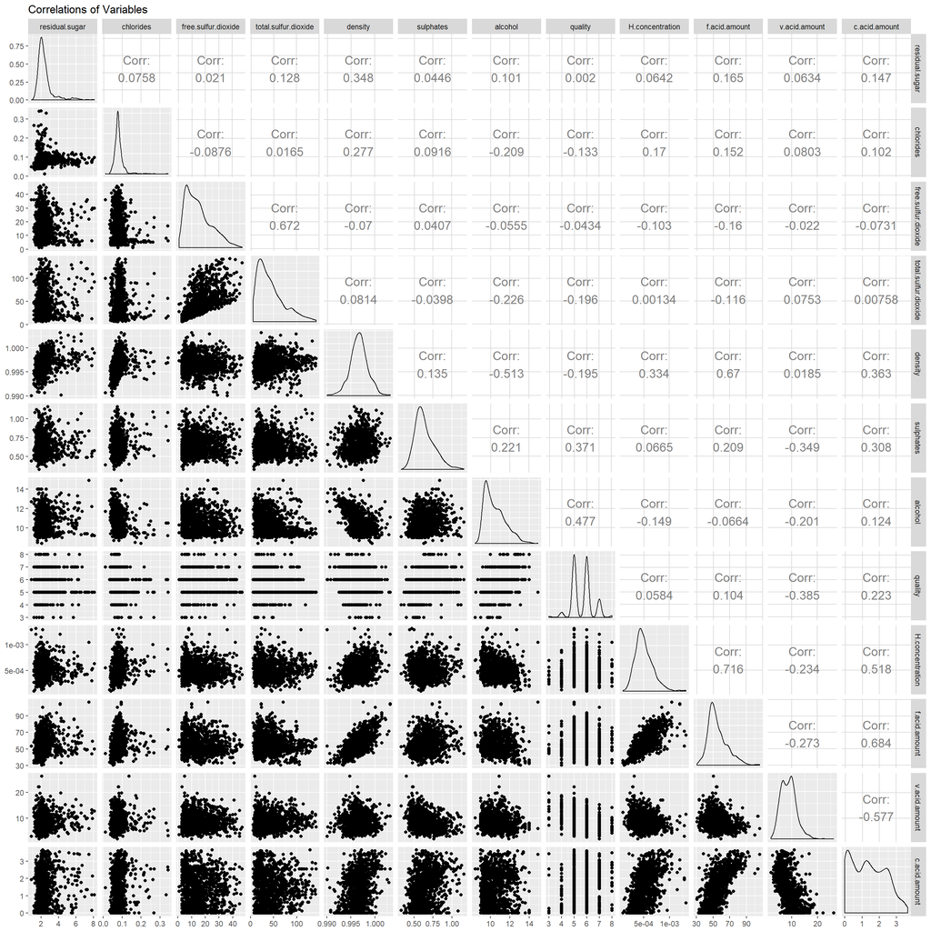

```r
# plot correlations of all the variables
library(GGally)

ggpairs(tidy.wine, upper = list(continuous = wrap('cor', size = 5))) +
  ggtitle('Correlations of Variables')
```

可以看到，部分变量间存在着一定线性关系，不过总体说来多数变量之间关系并不明显，这与之前的分析相符。

## 游离二氧化硫与总二氧化硫之间的关系

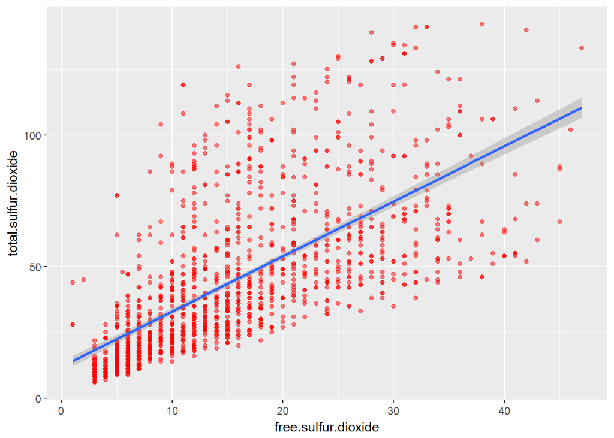

```r
ggplot(data = tidy.wine, mapping = aes(x = free.sulfur.dioxide, y = total.sulfur.dioxide)) +
        geom_point(alpha = 0.5, color = 'red') +
        geom_smooth(method = 'lm')
```

```r
cor.test(x = tidy.wine$free.sulfur.dioxide, y = tidy.wine$total.sulfur.dioxide)
```

```
##
##  Pearson's product-moment correlation
##
## data:  tidy.wine$free.sulfur.dioxide and tidy.wine$total.sulfur.dioxide
## t = 35.132, df = 1497, p-value < 2.2e-16
## alternative hypothesis: true correlation is not equal to 0
## 95 percent confidence interval:
##  0.6435096 0.6990746
## sample estimates:
##       cor
## 0.6722377
```

从线性分析结果可以看到：P值2.2e-16，远小于显著水平0.05、0.01，故线性回归效果显著。

## 密度与哪些变量相关

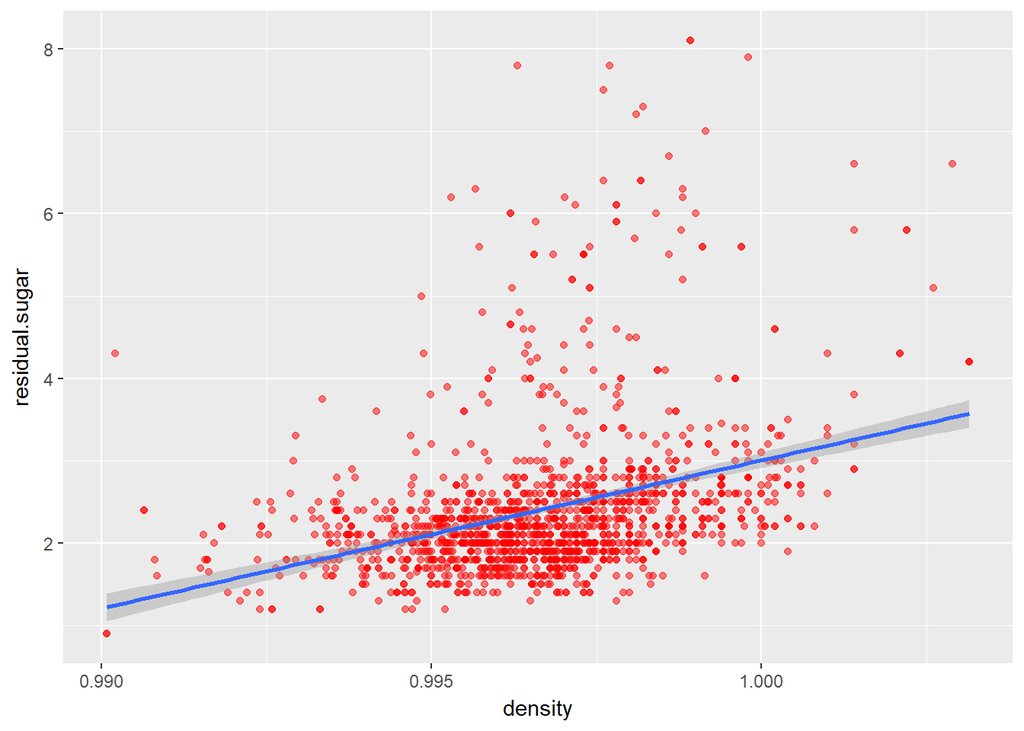

```r
# density vs residual.sugar/alcohol/f.acid.amount
ggplot(data = tidy.wine, mapping = aes(x = density, y = residual.sugar)) +
        geom_point(alpha = 0.5, color = 'red') +
        geom_smooth(method = 'lm')
```

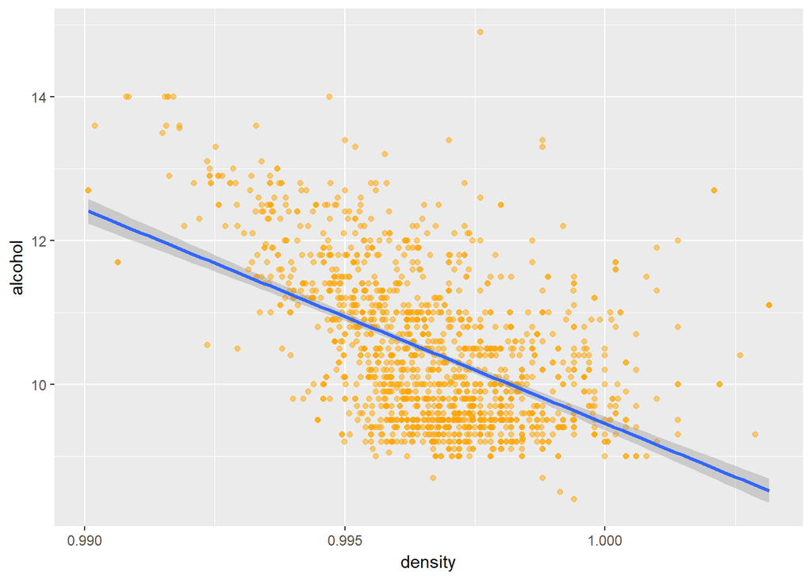

```r
ggplot(data = tidy.wine, mapping = aes(x = density, y = alcohol)) +
        geom_point(alpha = 0.5, color = 'orange') +
        geom_smooth(method = 'lm')
```

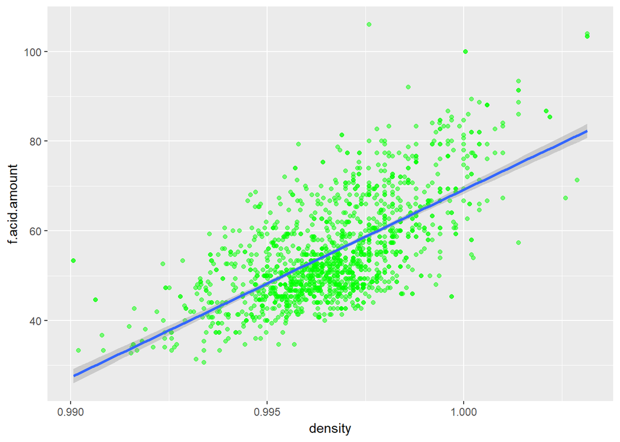

```r
ggplot(data = tidy.wine, mapping = aes(x = density, y = f.acid.amount)) +
        geom_point(alpha = 0.5, color = 'green') +
        geom_smooth(method = 'lm')
```

```r
cor.test(x = tidy.wine$density, y = tidy.wine$residual.sugar)
```

```
##
##  Pearson's product-moment correlation
##
## data:  tidy.wine$density and tidy.wine$residual.sugar
## t = 14.339, df = 1497, p-value < 2.2e-16
## alternative hypothesis: true correlation is not equal to 0
## 95 percent confidence interval:
##  0.3021914 0.3912515
## sample estimates:
##       cor
## 0.3475049
```

```r
cor.test(x = tidy.wine$density, y = tidy.wine$alcohol)
```

```
##
##  Pearson's product-moment correlation
##
## data:  tidy.wine$density and tidy.wine$alcohol
## t = -23.104, df = 1497, p-value < 2.2e-16
## alternative hypothesis: true correlation is not equal to 0
## 95 percent confidence interval:
##  -0.5490715 -0.4743774
## sample estimates:
##        cor
## -0.5126939
```

```r
cor.test(x = tidy.wine$density, y = tidy.wine$f.acid.amount)
```

```
##
##  Pearson's product-moment correlation
##
## data:  tidy.wine$density and tidy.wine$f.acid.amount
## t = 34.889, df = 1497, p-value < 2.2e-16
## alternative hypothesis: true correlation is not equal to 0
## 95 percent confidence interval:
##  0.6407658 0.6966795
## sample estimates:
##       cor
## 0.6696705
```

## 品质与硫酸盐、酒精含量、挥发性酸的关系

由于品质分数为离散值，这里按照各个变量相对品质分数做箱线图，首先需要将它转换成factor型。

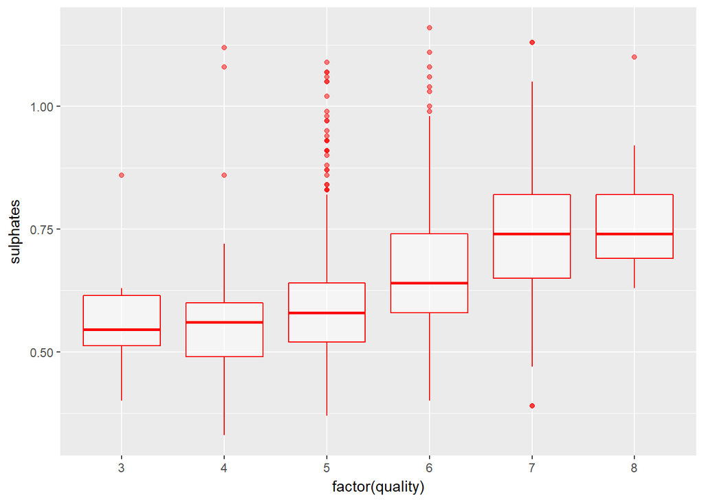

```r
# transform 'quality' from type of int into type of factor
ggplot(data = tidy.wine, mapping = aes(x = factor(quality), y = sulphates)) +
        geom_boxplot(alpha = 0.5, color = 'red')
```

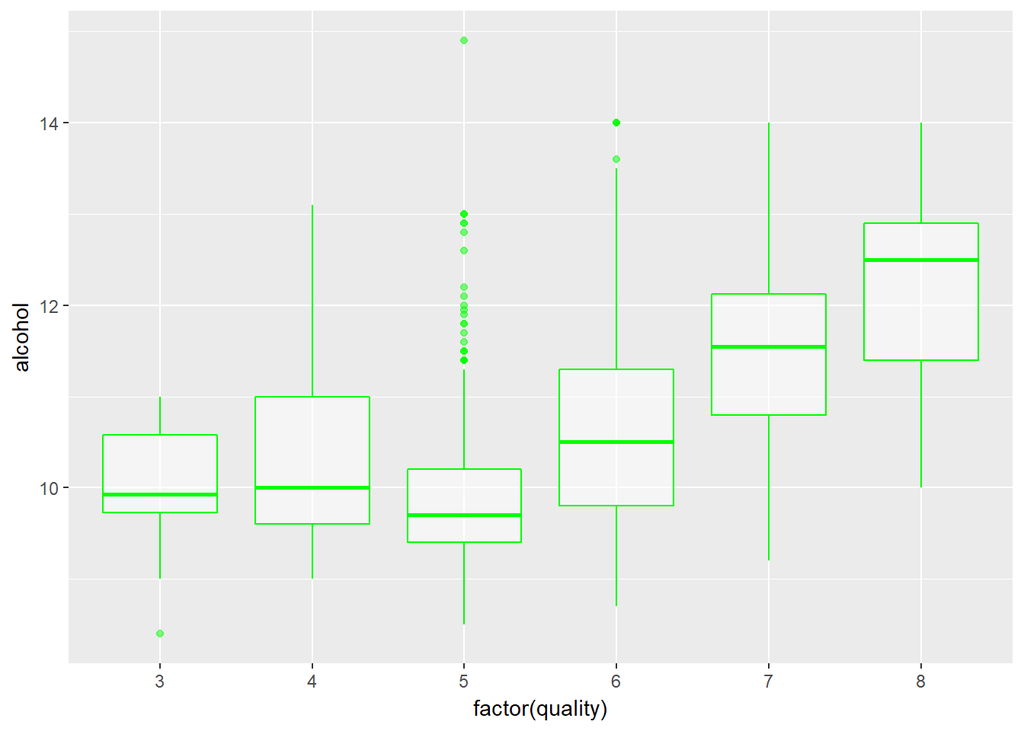

```r
ggplot(data = tidy.wine, mapping = aes(x = factor(quality), y = alcohol)) +
        geom_boxplot(alpha = 0.5, color = 'green')
```

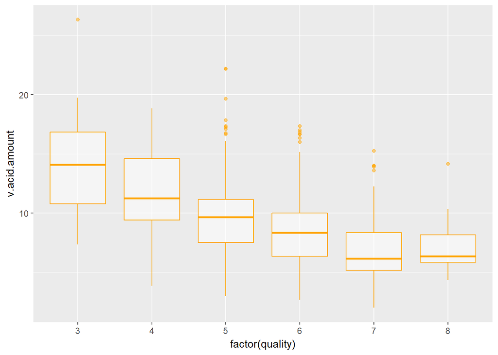

```r
ggplot(data = tidy.wine, mapping = aes(x = factor(quality), y = v.acid.amount)) +
        geom_boxplot(alpha = 0.5, color = 'orange')
```

可以看到，从中位数来看，三幅图的总趋势是随着品质的提高，硫酸盐、酒精含量趋向于上升，挥发性算含量趋于下降，说明品质与这三种成分的含量有关。

## 氢离子与密度、非挥发性酸、柠檬酸、挥发性酸的关系

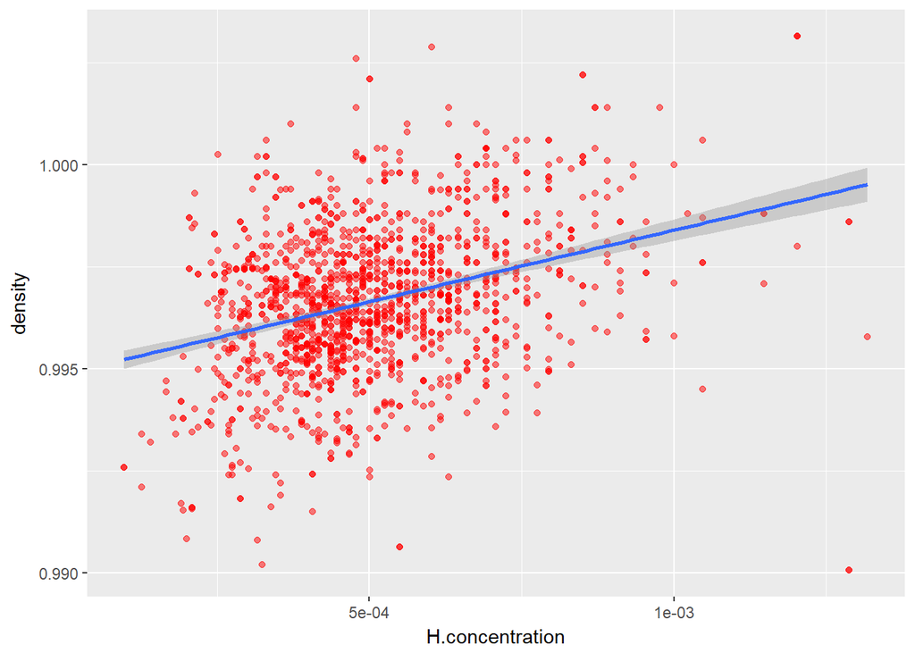

```r
# H.concentration vs density/f.acid.amount/c.acid.amount/v.acid.amount
ggplot(data = tidy.wine, mapping = aes(x = H.concentration, y = density)) +
        geom_point(alpha = 0.5, color = 'red') +
        geom_smooth(method = 'lm')
```

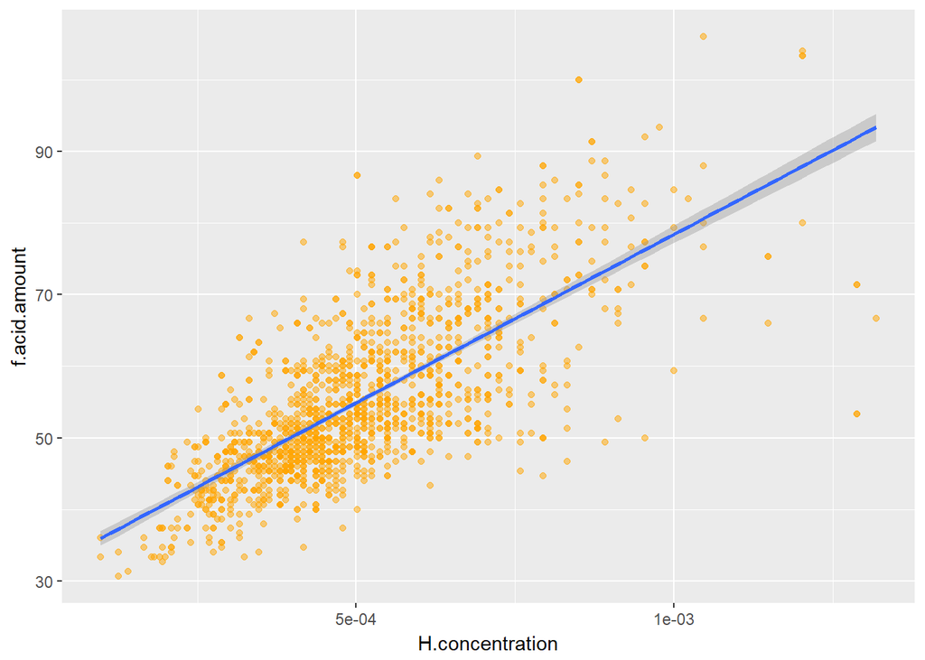

```r
ggplot(data = tidy.wine, mapping = aes(x = H.concentration, y = f.acid.amount)) +
        geom_point(alpha = 0.5, color = 'orange') +
        geom_smooth(method = 'lm')
```

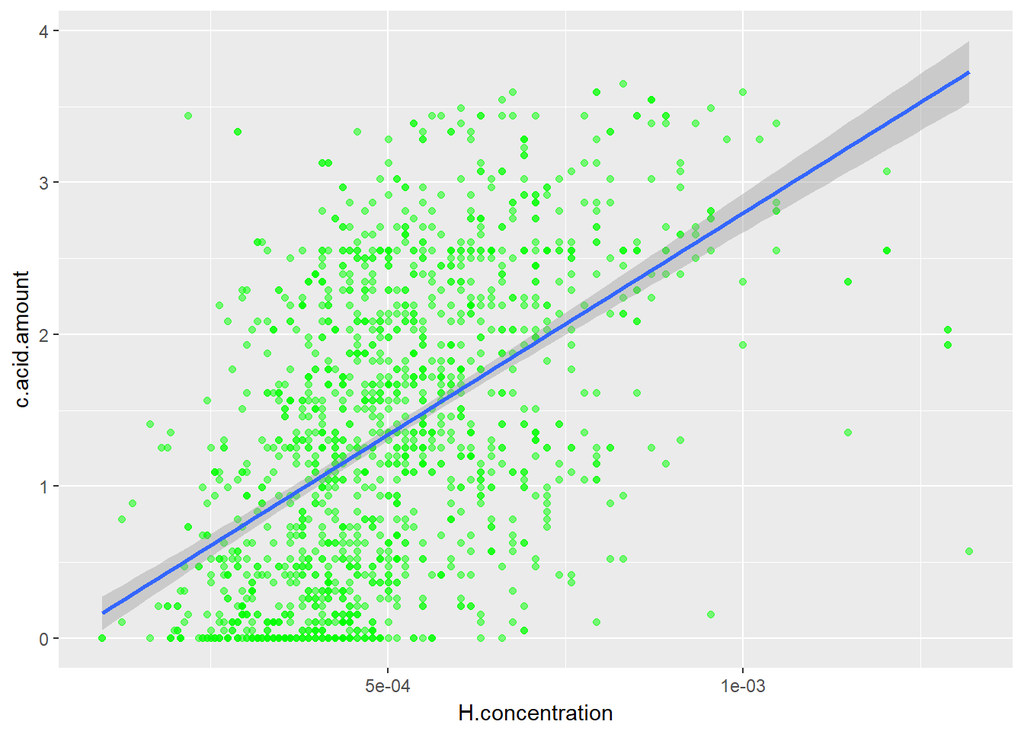

```r
ggplot(data = tidy.wine, mapping = aes(x = H.concentration, y = c.acid.amount)) +
        geom_point(alpha = 0.5, color = 'green') +
        geom_smooth(method = 'lm')
```

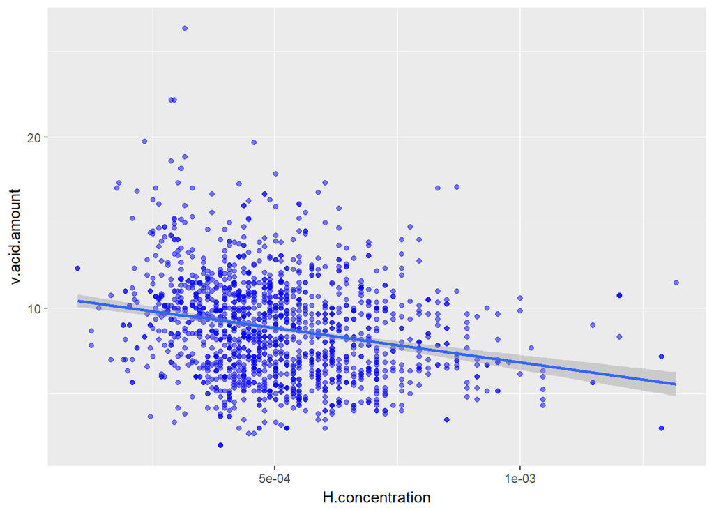

```r
ggplot(data = tidy.wine, mapping = aes(x = H.concentration, y = v.acid.amount)) +
        geom_point(alpha = 0.5, color = 'blue') +
        geom_smooth(method = 'lm')
```

```r
cor.test(x = tidy.wine$H.concentration, y = tidy.wine$density)
```

```
##
##  Pearson's product-moment correlation
##
## data:  tidy.wine$H.concentration and tidy.wine$density
## t = 13.712, df = 1497, p-value < 2.2e-16
## alternative hypothesis: true correlation is not equal to 0
## 95 percent confidence interval:
##  0.2882881 0.3782754
## sample estimates:
##       cor
## 0.3340427
```

```r
cor.test(x = tidy.wine$H.concentration, y = tidy.wine$f.acid.amount)
```

```
##
##  Pearson's product-moment correlation
##
## data:  tidy.wine$H.concentration and tidy.wine$f.acid.amount
## t = 39.734, df = 1497, p-value < 2.2e-16
## alternative hypothesis: true correlation is not equal to 0
## 95 percent confidence interval:
##  0.6908802 0.7402287
## sample estimates:
##       cor
## 0.7164495
```

```r
cor.test(x = tidy.wine$H.concentration, y = tidy.wine$c.acid.amount)
```

```
##
##  Pearson's product-moment correlation
##
## data:  tidy.wine$H.concentration and tidy.wine$c.acid.amount
## t = 23.43, df = 1497, p-value < 2.2e-16
## alternative hypothesis: true correlation is not equal to 0
## 95 percent confidence interval:
##  0.4799409 0.5540835
## sample estimates:
##       cor
## 0.5179844
```

```r
cor.test(x = tidy.wine$H.concentration, y = tidy.wine$v.acid.amount)
```

```
##
##  Pearson's product-moment correlation
##
## data:  tidy.wine$H.concentration and tidy.wine$v.acid.amount
## t = -9.3194, df = 1497, p-value < 2.2e-16
## alternative hypothesis: true correlation is not equal to 0
## 95 percent confidence interval:
##  -0.2814639 -0.1857425
## sample estimates:
##        cor
## -0.2341707
```